# 陈祉颖42205138期末考试

陈祉颖

2024-06-17

一、描述性统计 1.1

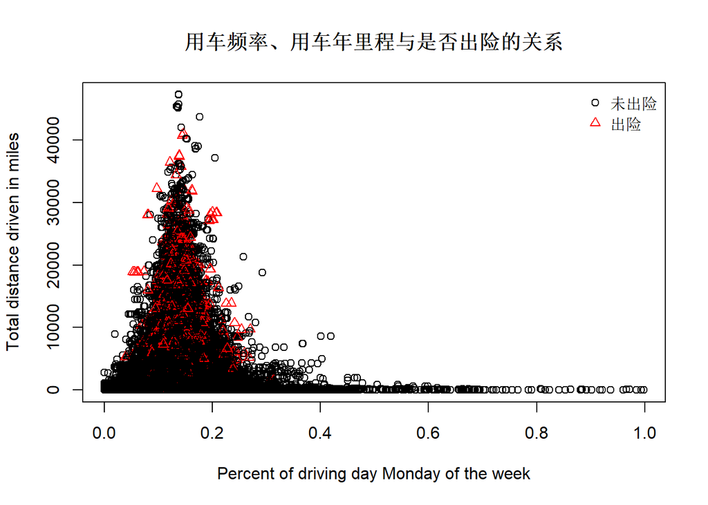

```r
df <- read.csv("D:/qq/1064914578/FileRecv/dt_final.csv")
dt <- read.csv("D:/qq/1064914578/FileRecv/dt_final.csv")
par(mfrow=c(1,1))
df$NB_Claim <- ifelse(df$NB_Claim >= 1, "出险", "未出险")
colors <- ifelse(df$NB_Claim == "出险", "red", "black")
shapes <- ifelse(df$NB_Claim == "出险", 2, 1)  # 17: 十字, 1: 圆圈
plot(x = df$Pct.drive.mon,
     y = df$Total.miles.driven,
     pch = shapes,  # 根据是否出险选择形状
     col = colors,  # 根据是否出险选择颜色
     xlab = 'Percent of driving day Monday of the week',
     ylab = 'Total distance driven in miles',
     main = '用车频率、用车年里程与是否出险的关系',
     type = "p")
legend("topright",
       legend = c("未出险", "出险"),
       pch = c(1, 2),  # 图例使用的点形状
       col = c("black", "red"),
       bty = "n")  # 图例的颜色
```

1.2

```r
filtered_data <- dt[dt$Pct.drive.mon >= 0.1 & dt$Pct.drive.mon <= 0.3 &
                          dt$Total.miles.driven >= 15000 & dt$Total.miles.driven <= 40000, ]

# 计算男性驾驶人群事故发生率
male_claims <- sum(filtered_data$NB_Claim[filtered_data$Insured.sex == "Male"] > 0)
male_total <- sum(filtered_data$Insured.sex == "Male")
male_accident_rate <- male_claims / male_total

# 计算女性驾驶人群事故发生率
female_claims <- sum(filtered_data$NB_Claim[filtered_data$Insured.sex == "Female"] > 0)
female_total <- sum(filtered_data$Insured.sex == "Female")
female_accident_rate <- female_claims / female_total

# 输出结果
cat("男性驾驶人群事故发生率:", male_accident_rate, "\n")
```

```
## 男性驾驶人群事故发生率: 0.1294896
```

```r
cat("女性驾驶人群事故发生率:", female_accident_rate, "\n")
```

```
## 女性驾驶人群事故发生率: 0.1219071
```

1.3

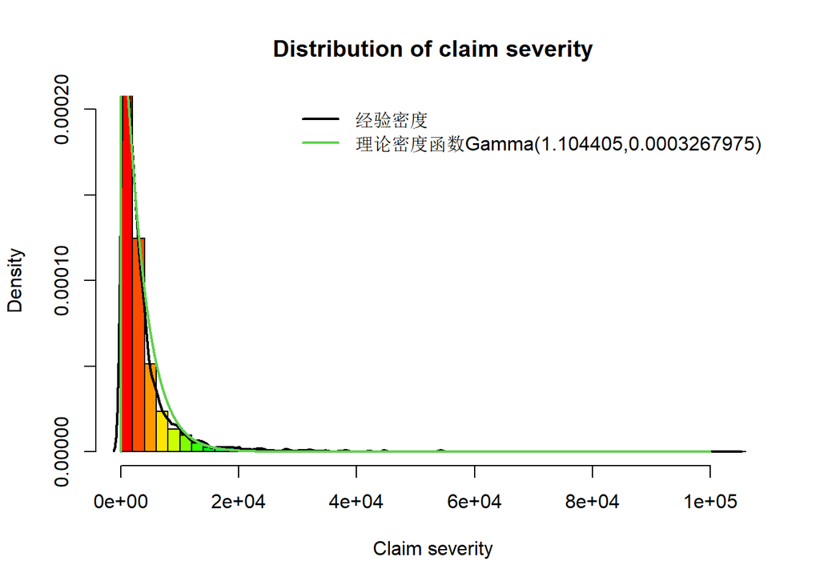

```r
dt0 <- subset(dt,dt$AMT_Claim>0)
dt0$severity <- dt0$AMT_Claim/dt0$NB_Claim
par(mfrow=c(1,1))
hist(dt0$severity,freq = F,breaks=50,col=rainbow(20),xlab='Claim severity',
     ylim=c(0.00000,0.00020),main='Distribution of claim severity')
flag <- density(dt0$AMT_Claim)#获取横纵坐标
lines(x=flag$x,y=flag$y,col=1,lty=1,lwd=2)
x0 <- seq(from=0,to=100000,length.out=10000)
y0 <- dgamma(x =x0 ,shape =1.104405,rate = 0.0003267975)
lines(x=x0,y=y0,col=3,lty=1,lwd=2)
legend('topright',c('经验密度','理论密度函数Gamma(1.104405,0.0003267975)'),
       col=c(1,3),lty=1,bty='n',lwd =2)
```

1.4

```r
# 使用理论分布模拟10万个索赔强度值
set.seed(123)  # 设置随机种子以确保可重复性
simulated_claims <- rgamma(n = 100000, shape = 1.104405, rate = 0.0003267975)

# 矩估计法计算期望值 μ
# 对于Gamma分布，期望值 μ = shape / rate
shape_estimate <- mean(simulated_claims)^2 / var(simulated_claims)
rate_estimate <- mean(simulated_claims) / var(simulated_claims)
mu_estimate <- shape_estimate / rate_estimate

cat("估计的期望值 μ:", mu_estimate, "\n")
```

```
## 估计的期望值 μ: 3388.16
```

二、回归 1.二阶段法

```r
 claims_data <- read.csv("D:/qq/1064914578/FileRecv/dt_final.csv")
  claims_data_filtered <- claims_data[claims_data$NB_Claim > 0, ]
  claims_data_filtered <- claims_data[claims_data$AMT_Claim > 0, ]
  claims_data_filtered$AVcost <- with(claims_data_filtered,
                                      ifelse(NB_Claim > 0, AMT_Claim / NB_Claim, NA))
  # 使用Gamma回归模型估计平均成本
  gamma_model <- glm(NB_Claim ~ Insured.age + Insured.sex + Car.age
                     +Marital+Car.use+Credit.score +Region+Annual.miles.drive+
                       Territory+Total.miles.driven+Annual.pct.driven+Avgdays.week,
                     family = Gamma(link = "log"),
                     data = claims_data_filtered)
  predicted_claims <- predict(gamma_model, type = "response")
  sum(predicted_claims)
```

```
## [1] 4080.966
```

```r
  sum(claims_data_filtered$NB_Claim)
```

```
## [1] 4081
```

```r
  gamma_model <- glm(AVcost ~Insured.age + Insured.sex + Car.age
                     +Marital+Car.use+Credit.score +Region+Annual.miles.drive+
                       Territory+Total.miles.driven+Annual.pct.driven+Avgdays.week,
                     data = claims_data_filtered,
                     family = Gamma(link = "log"))
  predicted_costs <- predict(gamma_model, type = "response")
  sum(predicted_costs)
```

```
## [1] 13089835
```

```r
  sum(claims_data_filtered$AVcost)
```

```
## [1] 13058305
```

```r
  pure_premium <- predicted_claims * predicted_costs
  sum(pure_premium)
```

```
## [1] 13823726
```

```r
  pure_premium_0 <- claims_data_filtered$NB_Claim * claims_data_filtered$AVcost
  sum(pure_premium_0)
```

```
## [1] 13760225
```

2.纯保费

```r
claims_data <- read.csv("D:/qq/1064914578/FileRecv/dt_final.csv")
claims_data_filtered <- claims_data[claims_data$AMT_Claim > 0, ]
# 使用Gamma回归模型估计平均成本
gamma_model <- glm(AMT_Claim ~ Insured.age + Insured.sex + Car.age
                   +Marital+Car.use+Credit.score +Region+Annual.miles.drive+
                     Territory+Total.miles.driven+Annual.pct.driven+Avgdays.week,
                   family = Gamma(link = "log"),
                   data = claims_data_filtered)
predicted_costs <- predict(gamma_model, type = "response")
sum(predicted_costs)
```

```
## [1] 13807906
```

```r
sum(claims_data_filtered$AMT_Claim)
```

```
## [1] 13760225
```

三、准备金评估

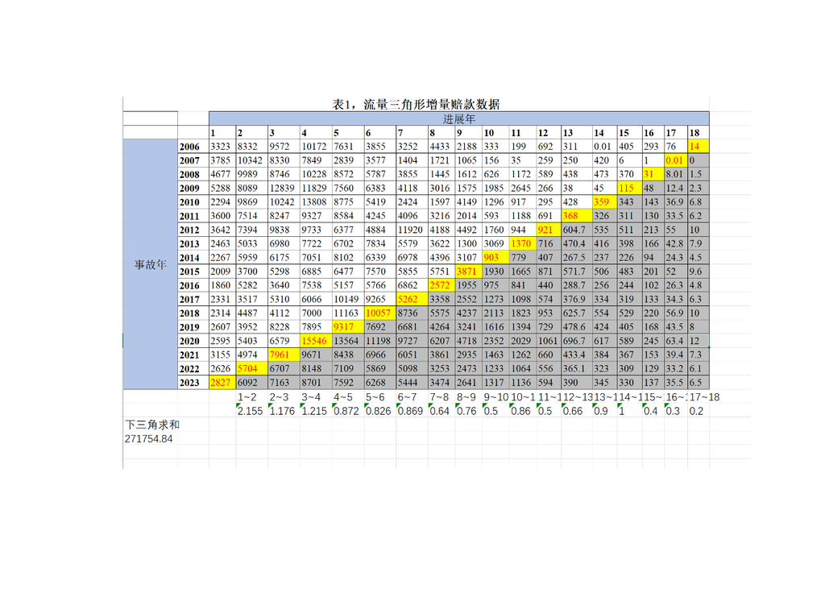

```r
library(png)
lt <- readPNG("~/WeChat Files/wxid_ttcng9afx4kt22/FileStorage/Temp/16af9af4d37fd8393ad535d6772c617.png")
plot(as.raster(lt))
```